# BIM 283 Homework 4

Hoang Trang Thy Trinh

2026-02-27

The data for problems 5.15, 5.18, and 5.20 are in the zipped data file. The latter two are labeled prb0519.dat and prb0521.dat

1. Do problem 5.1 in the text

```r
breaking_strength <- data.frame(Nickel =  factor(c(0, 3, 0, 3)), Manganese = factor(c(1, 1, 2, 2)), breaking_strength = c(35, 46, 42, 40))

lm5_15 <- lm(breaking_strength ~ Nickel*Manganese, data = breaking_strength)
coef(lm5_15)
```

```
##        (Intercept)            Nickel3         Manganese2 Nickel3:Manganese2
##                 35                 11                  7                -13
```

Find the main effects and interaction.

```r
#Main effects
#Difference between average breaking strength when nickel is high (3%) and when nickel is low (0%)

avg_nickel_hi <- (46+40)/2
avg_nickel_lo <- (35+42)/2
diff_avg_nickel <- avg_nickel_hi - avg_nickel_lo
diff_avg_nickel
```

```
## [1] 4.5
```

```r
#Main effects
#Difference between average breaking strength when manganese is high (2%) and when manganese is low (1%)

avg_mn_hi <- (42+40)/2
avg_mn_lo <- (35+46)/2
diff_avg_mn <- avg_mn_hi - avg_mn_lo
diff_avg_mn
```

```
## [1] 0.5
```

Since the difference of the average breaking strength between low and high level for nickel (4.5 ft-lb) is higher than that for manganese (0.5ft-lb), this might indicate that the main effect on breaking strength increase is dominated by the nickel level.

```r
#Interaction
#Difference between average breaking strength of (+) Ni and Mn interaction and average breaking strength of (-) Ni and Mn interaction
#Adding interaction column

breaking_strength$interaction = c("+", "-", "-", "+")

avg_ni_mn_pos <- (35+40)/2
avg_ni_mn_neg <- (46+42)/2
diff_avg <- avg_ni_mn_pos - avg_ni_mn_neg
diff_avg
```

```
## [1] -6.5
```

The -6.5 ft-lb interaction indicates that breaking strength increase contributed by Nickel is dampened by the addition of Manganese. Especially, from the lm(), high level of Nickel and high level of Manganese together can result in a decrease of -13 ft-lb.

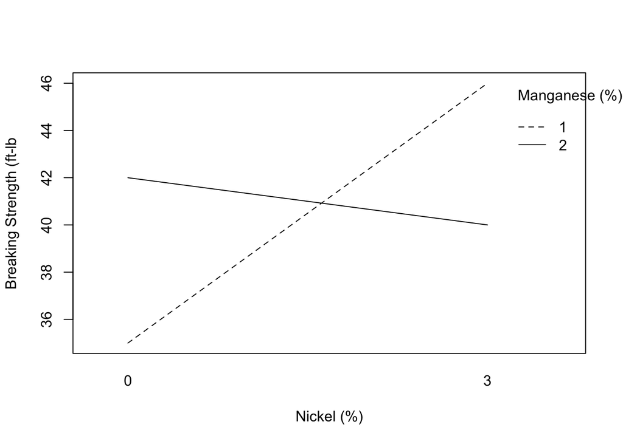

```r
#Interaction plot
interaction.plot(breaking_strength$Nickel, breaking_strength$Manganese, breaking_strength$breaking_strength,
                 xlab = "Nickel (%)",
                 ylab = "Breaking Strength (ft-lb",
                 trace.label = "Manganese (%)")
```

The interaction plot between Nickel and Manganese shows that there are influences that one factor has on the other. Specifically, without the the presence of Nickel (0%), breaking strength increases when Manganese is increased. When Nickel is at high level (3%), increasing Manganese reduces breaking strength. This shows that breaking strength is highest when mixing low level of Manganese with high level of Nickel.

2. Do problem 5.15 in the text

```r
metal_recov <- read.table("~/Desktop/Davis - WINTER 2026/BIM283/data/prb0515.dat", header = T)
```

1. Do you think that these data contain a discrepant value?

```r
#Discrepant value
metal_recov$discre <- metal_recov$y1 - metal_recov$y2
print(metal_recov$discre[1])
```

```
## [1] 18
```

There is one difference valued at 18 in one duplicate which is much higher than values of difference in other duplicates, indicating a potential discrepant value.

2. Perform an analysis using all the data and plot residuals

```r
#Convert metal_recov to long data table
metal_recov_long <- data.frame(temp = rep(metal_recov$temp, each = 2),
                               conc = rep(metal_recov$conc, each = 2),
                               time = rep(metal_recov$time, each =2),
                               y=c(rbind(metal_recov$y1,metal_recov$y2)))

metal_recov_long$temp = factor(metal_recov_long$temp)
metal_recov_long$conc = factor(metal_recov_long$conc)
metal_recov_long$time = factor(metal_recov_long$time)

metal_recov_long
```

```
##    temp conc time  y
## 1    -1   -1   -1 80
## 2    -1   -1   -1 62
## 3     1   -1   -1 65
## 4     1   -1   -1 63
## 5    -1    1   -1 69
## 6    -1    1   -1 73
## 7     1    1   -1 74
## 8     1    1   -1 80
## 9    -1   -1    1 81
## 10   -1   -1    1 79
## 11    1   -1    1 84
## 12    1   -1    1 86
## 13   -1    1    1 91
## 14   -1    1    1 93
## 15    1    1    1 93
## 16    1    1    1 93
```

```r
#ANOVA
metal_lm <- lm(y ~ temp * conc * time, data = metal_recov_long)
anova(metal_lm)
```

```
## Analysis of Variance Table
##
## Response: y
##                Df  Sum Sq Mean Sq F value    Pr(>F)
## temp            1    6.25    6.25  0.2551 0.6271225
## conc            1  272.25  272.25 11.1122 0.0103304 *
## time            1 1122.25 1122.25 45.8061 0.0001424 ***
## temp:conc       1   20.25   20.25  0.8265 0.3898448
## temp:time       1   12.25   12.25  0.5000 0.4995759
## conc:time       1   12.25   12.25  0.5000 0.4995759
## temp:conc:time  1   72.25   72.25  2.9490 0.1242610
## Residuals       8  196.00   24.50
## ---
## Signif. codes:  0 '***' 0.001 '**' 0.01 '*' 0.05 '.' 0.1 ' ' 1
```

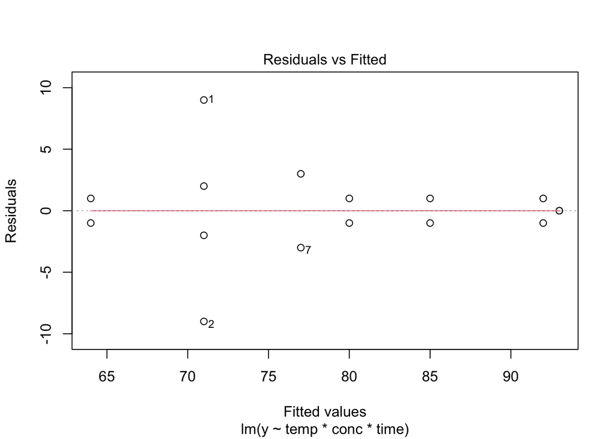

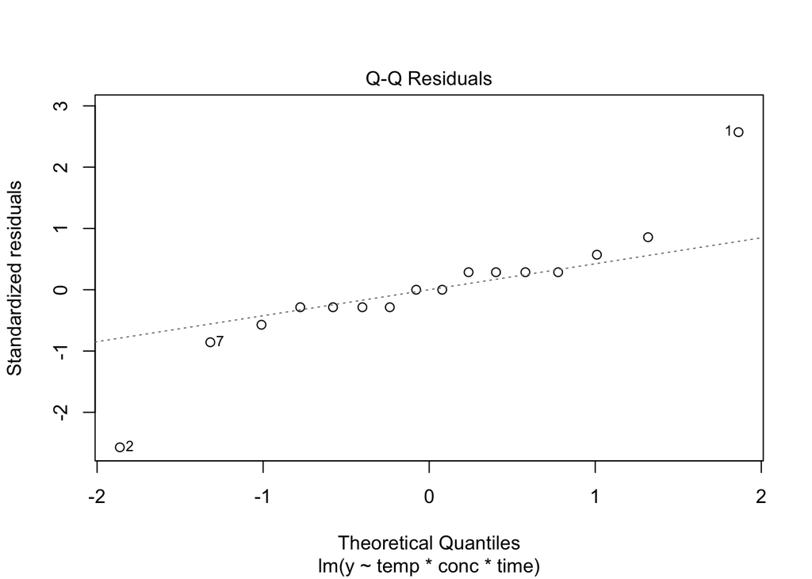

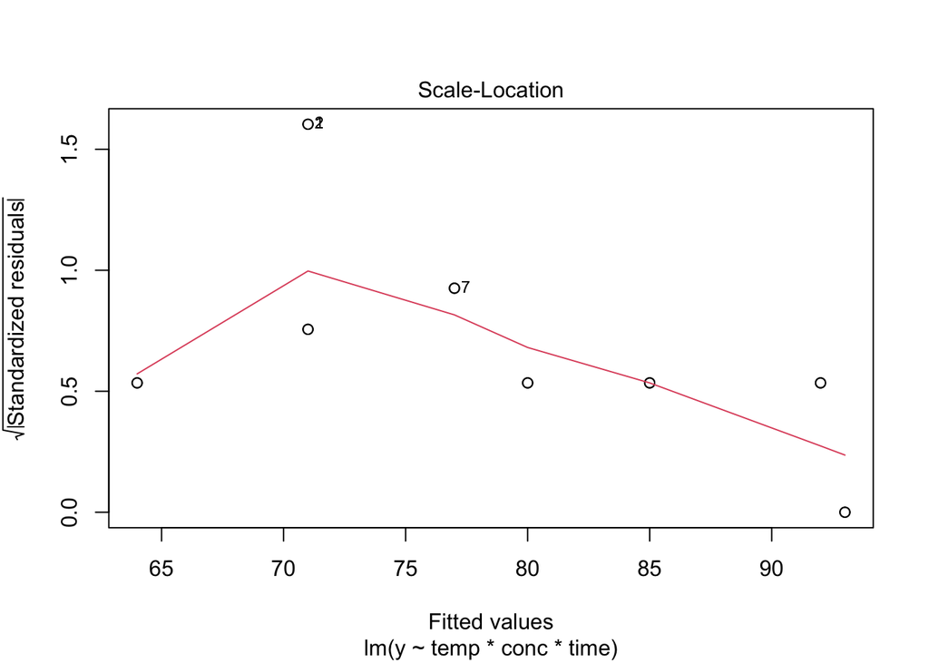

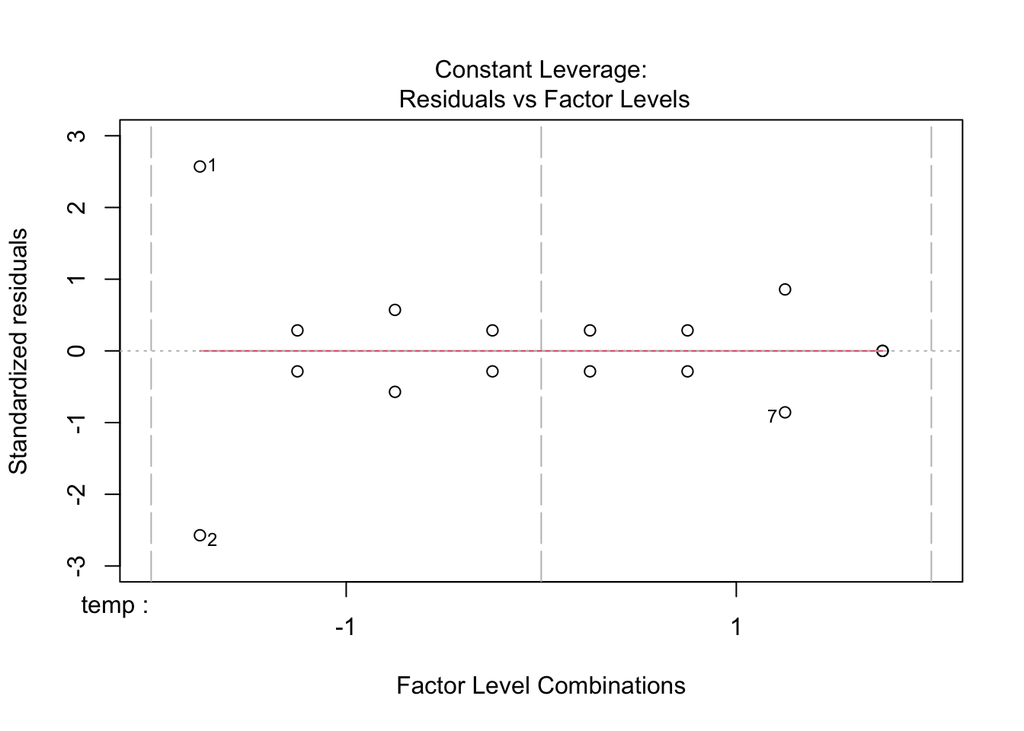

```r
#Residuals plot
plot(metal_lm)
```

(c) Perform an approximate analysis, omitting the discrepant value

```r
#Omitting one run (either 80 or 62) from the first duplicate that has the highest discrepancy calculated previously
#Omitting 80
omitted_80 <- metal_recov_long[-c(1),]
```

```r
#ANOVA on adjusted data set
omitted_80_lm <- lm(y ~ temp * conc * time, data = omitted_80)
anova(omitted_80_lm)
```

```
## Analysis of Variance Table
##
## Response: y
##                Df  Sum Sq Mean Sq  F value    Pr(>F)
## temp            1    8.00    8.00   1.6480    0.2401
## conc            1  308.62  308.62  63.5396 9.327e-05 ***
## time            1 1344.64 1344.64 276.8379 6.922e-07 ***
## temp:conc       1    0.03    0.03   0.0062    0.9393
## temp:time       1    1.54    1.54   0.3163    0.5914
## conc:time       1    1.88    1.88   0.3866    0.5538
## temp:conc:time  1   14.22   14.22   2.9281    0.1308
## Residuals       7   34.00    4.86
## ---
## Signif. codes:  0 '***' 0.001 '**' 0.01 '*' 0.05 '.' 0.1 ' ' 1
```

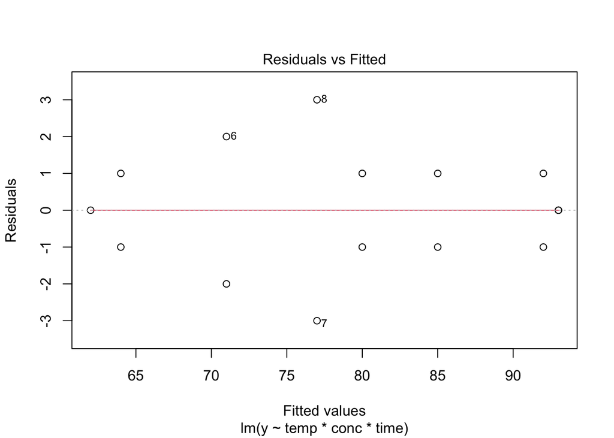

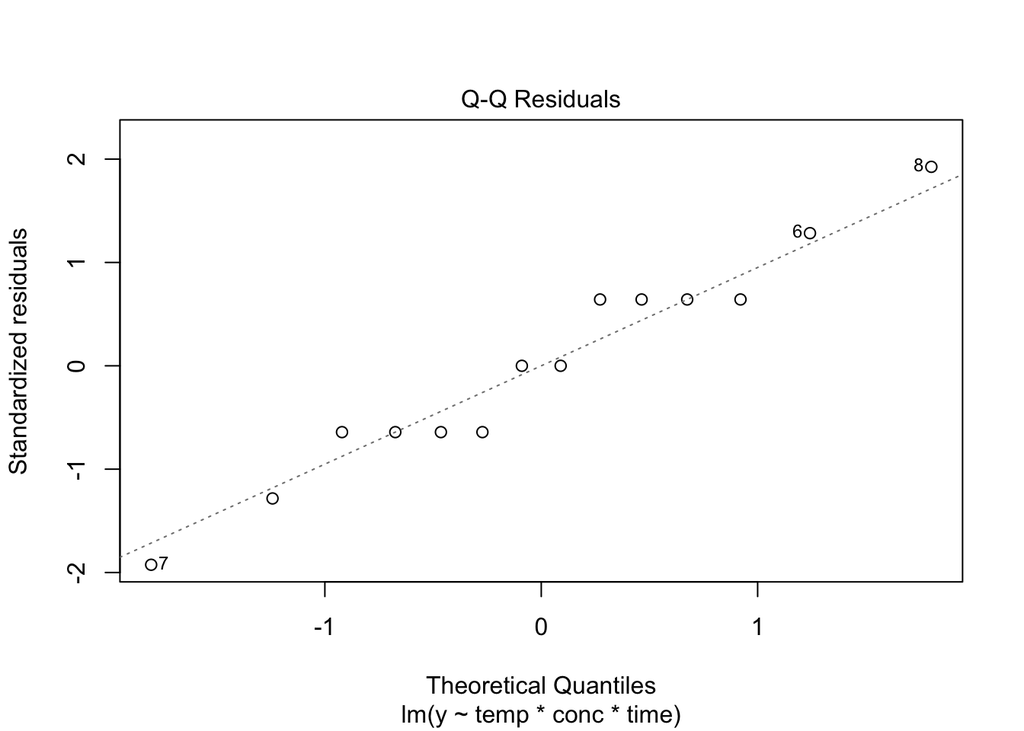

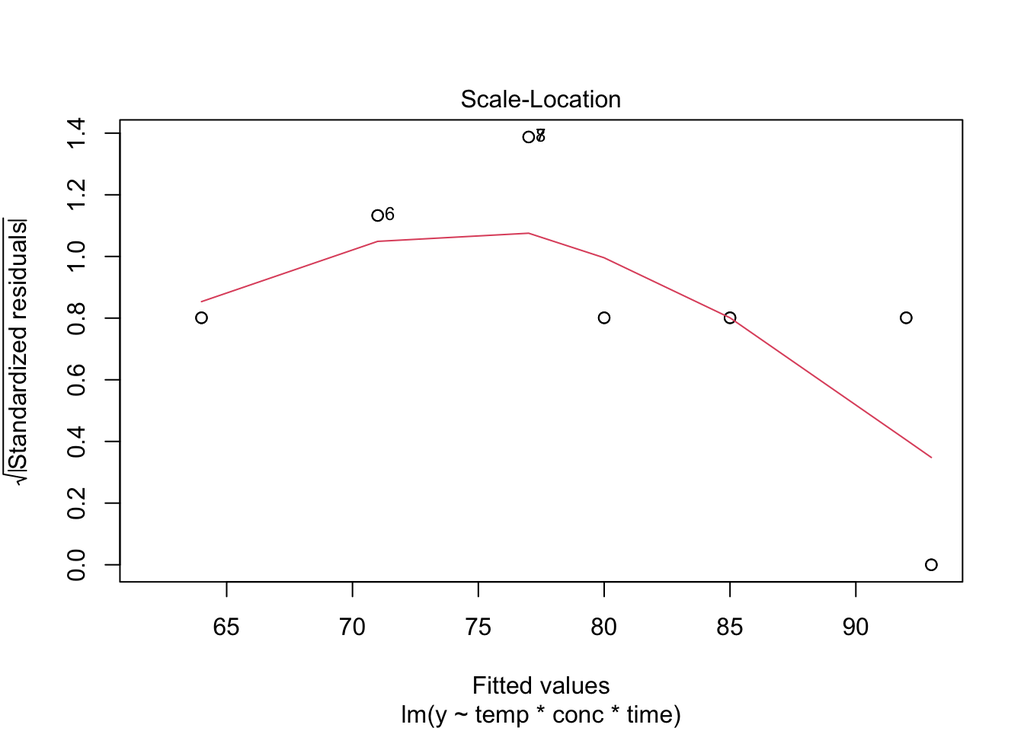

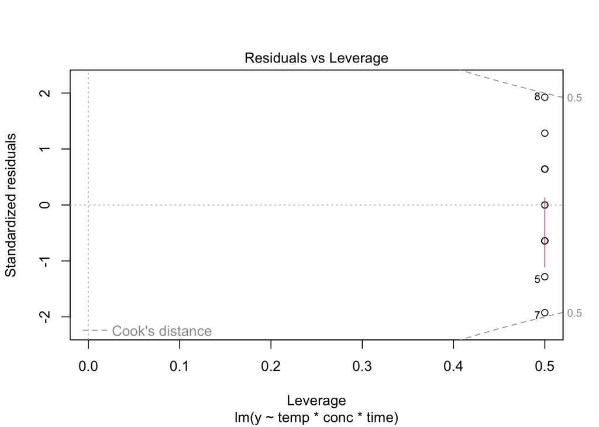

```r
#Residuals plot on data set without data point 80
plot(omitted_80_lm)
```

```r
#Omitting 62
omitted_62 <- metal_recov_long[-c(2),]
```

```r
#ANOVA on adjusted data set
omitted_62_lm <- lm(y ~ temp * conc * time, data = omitted_62)
anova(omitted_62_lm)
```

```
## Analysis of Variance Table
##
## Response: y
##                Df Sum Sq Mean Sq  F value    Pr(>F)
## temp            1   4.58    4.58   0.9422 0.3640597
## conc            1 149.59  149.59  30.7975 0.0008603 ***
## time            1 955.10  955.10 196.6388 2.222e-06 ***
## temp:conc       1  37.12   37.12   7.6426 0.0279133 *
## temp:time       1  31.65   31.65   6.5152 0.0379650 *
## conc:time       1  38.68   38.68   7.9631 0.0257034 *
## temp:conc:time  1 150.22  150.22  30.9281 0.0008497 ***
## Residuals       7  34.00    4.86
## ---
## Signif. codes:  0 '***' 0.001 '**' 0.01 '*' 0.05 '.' 0.1 ' ' 1
```

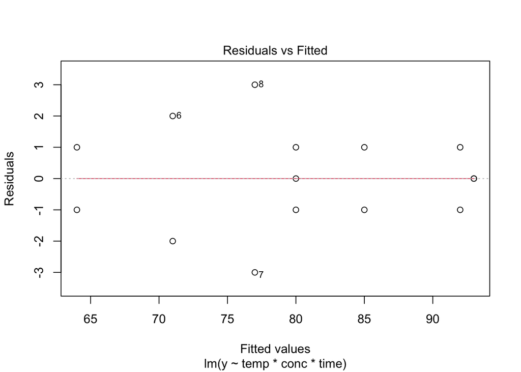

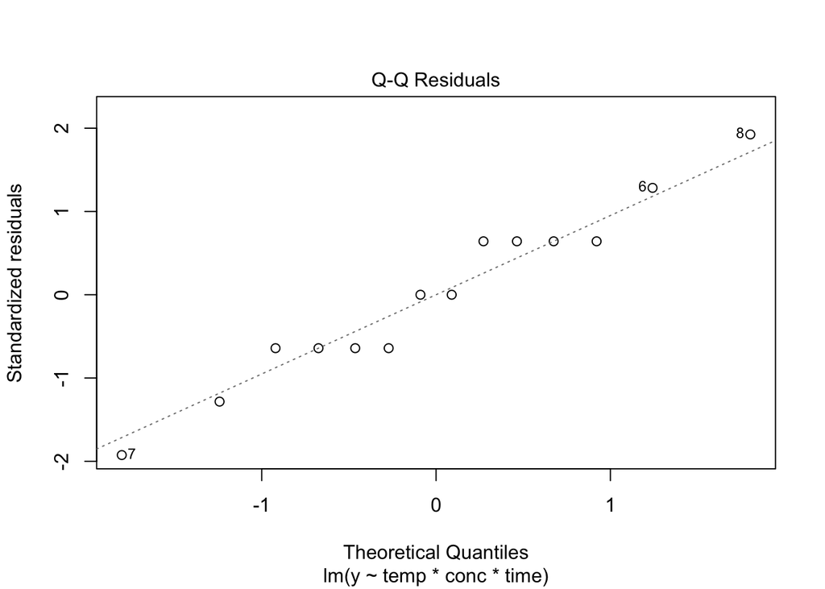

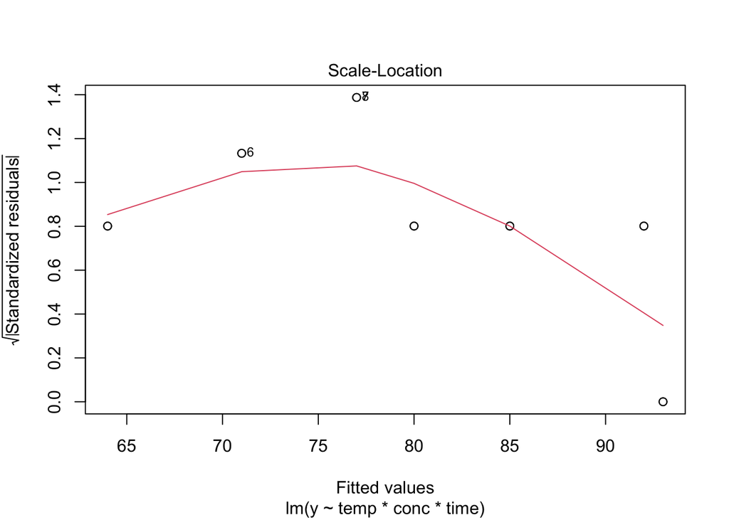

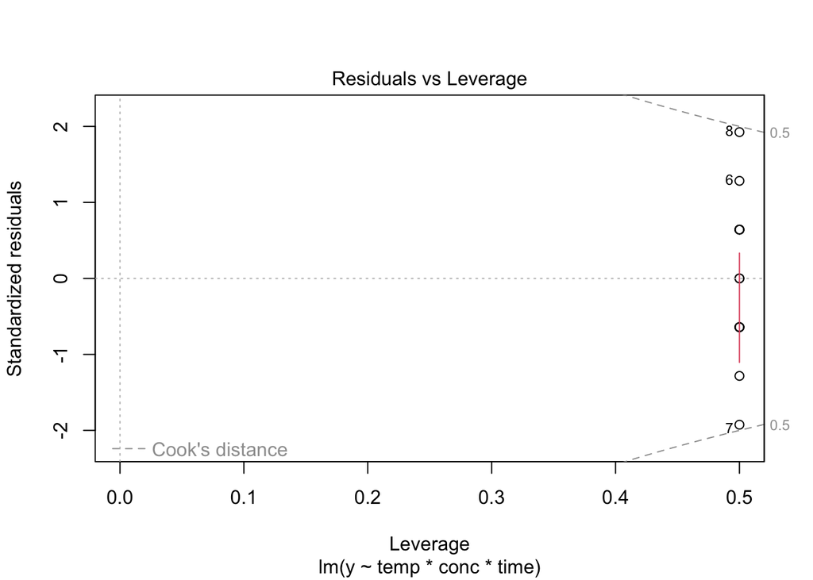

```r
#Residuals plot on data set without data point 80
plot(omitted_62_lm)
```

(d) Report your findings Assumptions used for performing ANOVA is that observations are independent, residuals following a normal distribution, and homoscedasticity.

Before omitting data, ANOVA model shows that time has the most significant effect on metal recovery level (p = 0.00014), followed by concentration (p = 0.01). After omitting either y = 62 or y = 80 from the first duplicate run, the residual mean square reduces from 24.50 to 4.86, indicating that this run might be the main contributor to the observed error. Both time and concentration remains the factor that affects the metal recovery level most significantly after the omission of either value. However, after omitting y = 62, all two-factor interactions and the only three-factor interaction show significant effect. This might indicate overfitting of the data, which might indicate that the variance was engineered (by omitting the data point) and the new significance observed for the interactions should be evaluated carefully.

3. Do problem 5.18 in the text Assumptions made are linearity, normal distribution of residuals, homoscedasticity, and independence of observations.

```r
algal_bloom <- read.table("~/Desktop/Davis - WINTER 2026/BIM283/data/prb0519.dat", header = T)
```

```r
#Set up estimate of variance and d.o.f
s2 = 0.003821
df = 18
se <- sqrt((4*s2)/8)
```

x1 = Phosphorus x2 = Nitrogen x3 = Carbon y1 = Algal pop after 4 days incubation y2 = Algal pop after 6 days incubation y3 = Algal pop after 8 days incubation y4 = Algal pop after 10 days incubation

*Analysis of variables on y1*

```r
#Analyzing effects of phosphorus, nitrogen, carbon, and their interactions on y1 using lm()
algal_y1 <- lm(y1 ~ x1*x2*x3, data = algal_bloom)
coef(algal_y1)
```

```
## (Intercept)          x1          x2          x3       x1:x2       x1:x3
##    0.420875    0.003875    0.005125    0.048125   -0.016375   -0.006875
##       x2:x3    x1:x2:x3
##   -0.016125    0.012375
```

```r
#Calculate effects
eff_y1 <-coef(algal_y1)[-1]*2
```

```r
#stats
t_y1 <- eff_y1 / se #Calculate t-values
p_val_y1 <- 2 * (1 - pt(abs(t_y1), df = df)) #Calculate two-sided p-values
p_val_y1
```

```
##         x1         x2         x3      x1:x2      x1:x3      x2:x3   x1:x2:x3
## 0.86124647 0.81724046 0.04094095 0.46337542 0.75669880 0.47012833 0.57822185
```

Carbon (x3) independently has the most significant effect on algal bloom after 4 day incubation, indicated by the largest absolute value of coefficient and a p-value of 0.0409 (<0.05).

*Analysis of variables on y2*

```r
#Analyzing effects of phosphorus, nitrogen, carbon, and their interactions on y2 using lm()
algal_y2 <- lm(y2 ~ x1*x2*x3, data = algal_bloom)
coef(algal_y2)
```

```
## (Intercept)          x1          x2          x3       x1:x2       x1:x3
##     0.50275    -0.04175     0.02475     0.15900     0.02375     0.05550
##       x2:x3    x1:x2:x3
##     0.02600     0.01800
```

```r
#Calculate effects
eff_y2 <-coef(algal_y2)[-1]*2
```

```r
#stats
t_y2 <- eff_y2 / se #Calculate t-values
p_val_y2 <- 2 * (1 - pt(abs(t_y2), df = df)) #Calculate two-sided p-values
p_val_y2
```

```
##           x1           x2           x3        x1:x2        x1:x3        x2:x3
## 7.215217e-02 2.722924e-01 9.218565e-07 2.914969e-01 2.054532e-02 2.496288e-01
##     x1:x2:x3
## 4.209325e-01
```

Carbon (x3) still has the strongest effect on algal population after 6 days incubation (p << 0.05). This time, the interaction between Phosphorus and Carbon (x1:x3) also takes effect in supporting the algal growth (coefficient = 0.055), with p-value = 0.0205. Phosphorus (x1) has an almost statistically negative effect on algal bloom, with the coefficient of -0.04 and p-value of 0.072.

*Analysis of variables on y3*

```r
#Analyzing effects of phosphorus, nitrogen, carbon, and their interactions on y1
algal_y3 <- lm(y3 ~ x1*x2*x3, data = algal_bloom)
coef(algal_y3)
```

```
## (Intercept)          x1          x2          x3       x1:x2       x1:x3
##    0.525375   -0.036625   -0.017625    0.183875    0.036375    0.049875
##       x2:x3    x1:x2:x3
##    0.083375   -0.010625
```

```r
#Calculate effects
eff_y3 <-coef(algal_y3)[-1]*2
```

```r
#stats
t_y3 <- eff_y3 / se #Calculate t-values
p_val_y3 <- 2 * (1 - pt(abs(t_y3), df = df)) #Calculate two-sided p-values
p_val_y3
```

```
##           x1           x2           x3        x1:x2        x1:x3        x2:x3
## 1.110514e-01 4.305017e-01 1.186788e-07 1.133418e-01 3.486533e-02 1.268334e-03
##     x1:x2:x3
## 6.327148e-01
```

Carbon (x3) continues to have the strongest positive influence on algal bloom after 8 days of incubation (p << 0.05). There are two two-factor interactions, Phosphorus and Carbon (x1:x3, p = 0.0348) and Nitrogen and Carbon (x2:x3, p = 0.00126) that shows effect on increasing algal population at this time.

*Analysis of variables on y4*

```r
#Analyzing effects of phosphorus, nitrogen, carbon, and their interactions on y1
algal_y4 <- lm(y4 ~ x1*x2*x3, data = algal_bloom)
coef(algal_y4)
```

```
## (Intercept)          x1          x2          x3       x1:x2       x1:x3
##      0.5310     -0.0105      0.0370      0.1705     -0.0020      0.0325
##       x2:x3    x1:x2:x3
##      0.0010      0.0395
```

```r
#Calculate effects
eff_y4 <-coef(algal_y4)[-1]*2
```

```r
#stats
t_y4 <- eff_y4 / se #Calculate t-values
p_val_y4 <- 2 * (1 - pt(abs(t_y4), df = df)) #Calculate two-sided p-values
p_val_y4
```

```
##           x1           x2           x3        x1:x2        x1:x3        x2:x3
## 6.366966e-01 1.076901e-01 3.498217e-07 9.280951e-01 1.542965e-01 9.640078e-01
##     x1:x2:x3
## 8.744343e-02
```

After 10 days of incubation, Carbon (x3) shows to be the sole factor contributing the growth of algal population (p << 0.05). However, the three-factor interaction (x1:x2:x3) seems to show some effect with p-value = 0.087, which might imply that the interactions of the three factors might play an interesting role as the algal population reaches certain threshold. Additional time points later than 10 days can be added to further explore this relationship.

4. Do problem 5.20 in the text. You don’t have to do part (f).

```r
impurity <- read.table("~/Desktop/Davis - WINTER 2026/BIM283/data/prb0521.dat", header = T)
```

1. Make a table of plus and minus signs from which the various effects and interactions could be calculated.

```r
#Make interactions table
impurity$AB <- impurity$x1*impurity$x2
impurity$AC <- impurity$x1*impurity$x3
impurity$AD <- impurity$x1*impurity$x4
impurity$BC <- impurity$x2*impurity$x3
impurity$BD <- impurity$x2*impurity$x4
impurity$CD <- impurity$x3*impurity$x4

impurity$ABC <- impurity$x1*impurity$x2*impurity$x3
impurity$ABD <- impurity$x1*impurity$x2*impurity$x4
impurity$ACD <- impurity$x1*impurity$x3*impurity$x4
impurity$BCD <- impurity$x2*impurity$x3*impurity$x4

impurity$ABCD <- impurity$x1*impurity$x2*impurity$x3*impurity$x4
impurity
```

```
##    order x1 x2 x3 x4 impurity AB AC AD BC BD CD ABC ABD ACD BCD ABCD
## 1      2 -1 -1 -1 -1     0.38  1  1  1  1  1  1  -1  -1  -1  -1    1
## 2      6  1 -1 -1 -1     0.40 -1 -1 -1  1  1  1   1   1   1  -1   -1
## 3     12 -1  1 -1 -1     0.27 -1  1  1 -1 -1  1   1   1  -1   1   -1
## 4      4  1  1 -1 -1     0.30  1 -1 -1 -1 -1  1  -1  -1   1   1    1
## 5      1 -1 -1  1 -1     0.58  1 -1  1 -1  1 -1   1  -1   1   1   -1
## 6      7  1 -1  1 -1     0.56 -1  1 -1 -1  1 -1  -1   1  -1   1    1
## 7     14 -1  1  1 -1     0.30 -1 -1  1  1 -1 -1  -1   1   1  -1    1
## 8      3  1  1  1 -1     0.32  1  1 -1  1 -1 -1   1  -1  -1  -1   -1
## 9      8 -1 -1 -1  1     0.59  1  1 -1  1 -1 -1  -1   1   1   1   -1
## 10    10  1 -1 -1  1     0.62 -1 -1  1  1 -1 -1   1  -1  -1   1    1
## 11    15 -1  1 -1  1     0.53 -1  1 -1 -1  1 -1   1  -1   1  -1    1
## 12    11  1  1 -1  1     0.50  1 -1  1 -1  1 -1  -1   1  -1  -1   -1
## 13    16 -1 -1  1  1     0.79  1 -1 -1 -1 -1  1   1   1  -1  -1    1
## 14     9  1 -1  1  1     0.75 -1  1  1 -1 -1  1  -1  -1   1  -1   -1
## 15     5 -1  1  1  1     0.53 -1 -1 -1  1  1  1  -1  -1  -1   1   -1
## 16    13  1  1  1  1     0.54  1  1  1  1  1  1   1   1   1   1    1
```

2. Calculate the effects.

```r
groups <- c("x1", "x2", "x3", "x4", "AB", "AC", "AD", "BC", "BD", "CD", "ABC", "ABD", "ACD", "BCD", "ABCD")

effect <- sapply(groups, function(col) sum(impurity[[col]] * impurity$impurity) / 8)
effect
```

```
##      x1      x2      x3      x4      AB      AC      AD      BC      BD      CD
##  0.0025 -0.1725  0.0975  0.2175  0.0050 -0.0100 -0.0100 -0.0750  0.0100 -0.0050
##     ABC     ABD     ACD     BCD    ABCD
##  0.0175 -0.0075  0.0025  0.0025  0.0100
```

3. Assuming three-factor and higher order interactions to be zero, compute and estimate of the error variance.

```r
hi_interactions <- c("ABC", "ACD", "ABD", "BCD", "ABCD")
error_var <- 4 * sum(effect[hi_interactions]^2)
error_df = 5
MSE <- error_var / error_df
MSE_sd <- sqrt(MSE)
cat("Estimated Error Variance =", MSE, "\n")
```

```
## Estimated Error Variance = 0.00038
```

```r
cat("Standard Deviation of Estimated Error Variance =", MSE_sd, "\n")
```

```
## Standard Deviation of Estimated Error Variance = 0.01949359
```

4. Make normal plots.

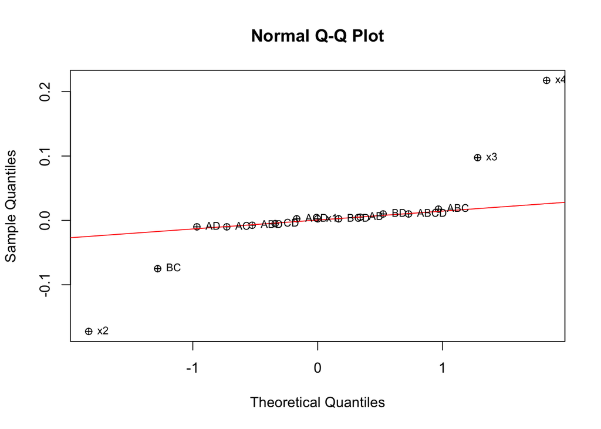

```r
qq_plot <- qqnorm(effect,
                  pch = 10, col = "black")
qqline(effect, col="red")

text(qq_plot$x, qq_plot$y,
     labels = groups,
     pos = 4, cex = 0.75)
```

5. Write a report, setting out the conclusions to be drawn from the experiment, and make recommendations. (Assume that the present conditions of operation are as follows: 1 = 5%, 2 = 40%, 3 = 10rpm, 4 = 180oF)